# DATA 608 - Module 1

Esteban Aramayo

2022-02-13

```r
> library(dplyr)
> library(ggplot2)
> library(kableExtra)
> library(viridis)
```

**Principles of Data Visualization and Introduction to ggplot2**

I have provided you with data about the 5,000 fastest growing companies in the US, as compiled by Inc. magazine. lets read this in:

```r
>
> inc <- read.csv("https://raw.githubusercontent.com/charleyferrari/CUNY_DATA_608/master/module1/Data/inc5000_data.csv", header= TRUE)
```

And lets preview this data:

```r
>
> head(inc)
  Rank                         Name Growth_Rate   Revenue
1    1                         Fuhu      421.48 1.179e+08
2    2        FederalConference.com      248.31 4.960e+07
3    3                The HCI Group      245.45 2.550e+07
4    4                      Bridger      233.08 1.900e+09
5    5                       DataXu      213.37 8.700e+07
6    6 MileStone Community Builders      179.38 4.570e+07
                      Industry Employees         City State
1 Consumer Products & Services       104   El Segundo    CA
2          Government Services        51     Dumfries    VA
3                       Health       132 Jacksonville    FL
4                       Energy        50      Addison    TX
5      Advertising & Marketing       220       Boston    MA
6                  Real Estate        63       Austin    TX
```

```r
>
> summary(inc)
      Rank          Name            Growth_Rate         Revenue
 Min.   :   1   Length:5001        Min.   :  0.340   Min.   :2.000e+06
 1st Qu.:1252   Class :character   1st Qu.:  0.770   1st Qu.:5.100e+06
 Median :2502   Mode  :character   Median :  1.420   Median :1.090e+07
 Mean   :2502                      Mean   :  4.612   Mean   :4.822e+07
 3rd Qu.:3751                      3rd Qu.:  3.290   3rd Qu.:2.860e+07
 Max.   :5000                      Max.   :421.480   Max.   :1.010e+10

   Industry           Employees           City              State
 Length:5001        Min.   :    1.0   Length:5001        Length:5001
 Class :character   1st Qu.:   25.0   Class :character   Class :character
 Mode  :character   Median :   53.0   Mode  :character   Mode  :character
                    Mean   :  232.7
                    3rd Qu.:  132.0
                    Max.   :66803.0
                    NA's   :12
```

Think a bit on what these summaries mean. Use the space below to add some more relevant non-visual exploratory information you think helps you understand this data:

```r
>
> # Insert your code here, create more chunks as necessary
>
```

## Question 1

Create a graph that shows the distribution of companies in the dataset by State (ie how many are in each state). There are a lot of States, so consider which axis you should use. This visualization is ultimately going to be consumed on a ‘portrait’ oriented screen (ie taller than wide), which should further guide your layout choices.

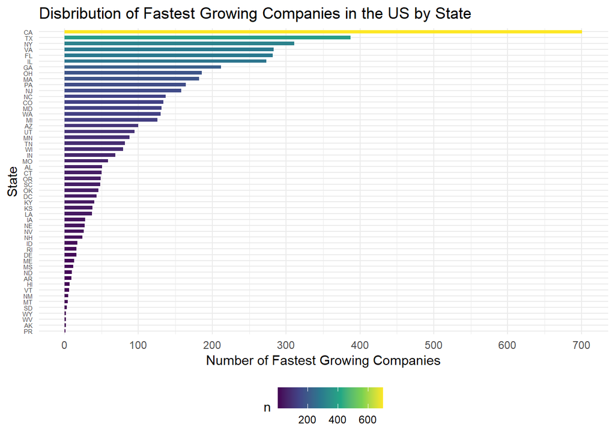

```r
>
> # Answer Question 1 here
>
> # Calculate the distribution of companies per State and sort it in descending order
> comp_dist <- inc %>%
+   group_by(State) %>%
+   summarise(n = n()) %>%
+   arrange(desc(n))
>
> ggplot(data = comp_dist, aes(x = reorder(State, n), y = n, fill = n)) +
+   geom_col(position = position_dodge(), width = 0.6) +
+   scale_y_continuous(breaks = seq(0,800,100)) +
+   coord_flip() +
+   ggtitle("Disbribution of Fastest Growing Companies in the US by State") +
+   labs(x = "State", y = "Number of Fastest Growing Companies") +
+   theme_minimal() +
+   theme(legend.position = "bottom") +
+   theme(
+     axis.text.y = element_text(size = rel(0.6))
+   ) +
+   scale_fill_viridis_c()   # add color palette that can also be distinguished by colorblind viewers
```

## Question 2

Lets dig in on the state with the 3rd most companies in the data set. Imagine you work for the state and are interested in how many people are employed by companies in different industries. Create a plot that shows the average and/or median employment by industry for companies in this state (only use cases with full data, use R’s `complete.cases()` function.) In addition to this, your graph should show how variable the ranges are, and you should deal with outliers.

```r
>
> # Answer Question 2 here
>
> Top_3_States <- inc %>%
+   group_by(State) %>%
+   summarise(n = n()) %>%
+   arrange(desc(n)) %>%
+   top_n(3)
>
> Top_3_States
# A tibble: 3 x 2
  State     n
  <chr> <int>
1 CA      701
2 TX      387
3 NY      311
```

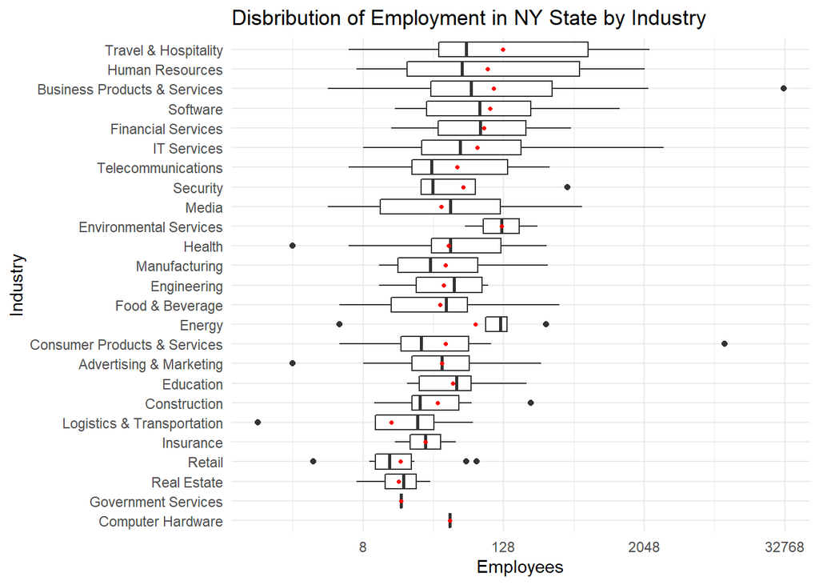

```r
> Third_top_State <- inc[complete.cases(Top_3_States),] %>%
+   filter(State == "NY") %>%
+   select(State, Industry, Employees)
>
> # Reorder Industry by IQR to show employment variability in descending order
> ggplot(data = Third_top_State,
+        mapping = aes(x = reorder(Industry, Employees, FUN = IQR),
+                      y = Employees)) +
+   geom_boxplot() +
+   ggtitle("Disbribution of Employment in NY State by Industry") +
+   labs(x = "Industry", y = "Employees") +
+   coord_flip() +
+   stat_summary(fun.y = mean, geom = "point", shape = 20, color="red", fill="red") + # add mean to graph
+   scale_y_continuous(trans = scales::log2_trans()) +  # transform y values to reduce box compression due to extreme outliers
+   theme_minimal() +
+   scale_fill_viridis_c()   # add color palette that can also be distinguished by colorblind viewers
```

## Question 3

Now imagine you work for an investor and want to see which industries generate the most revenue per employee. Create a chart that makes this information clear. Once again, the distribution per industry should be shown.

```r
>
> # Answer Question 3 here
>
```

[output not shown]